# Measuring the performance of weight lifting

Luca

28/7/2021

## Introduction

The aim of this analysis is to measure the performance of different kind of physical exercises. One common behavior is to measure how much activity one person is carrying out; however, it is important to understand how well these activities are performed as well. To do so, we’ll be using data coming from the [Human Activity Recognition project](https://web.archive.org/web/20161224072740/http:/groupware.les.inf.puc-rio.br/har).

## Exploratory Analysis

After having set a seed for reproducibility, we upload the data

```r
# loading caret package
library(caret)
library(e1071)
library(rattle)
# train and test data uploading
TrainData = read.csv("./pml-training.csv")
TestData = read.csv("./pml-testing.csv")
```

Let’s have a look at these data

```r
dim(TrainData)
```

```
## [1] 19622   160
```

```r
dim(TestData)
```

```
## [1]  20 160
```

```r
names(TrainData)
```

```
##   [1] "X"                        "user_name"
##   [3] "raw_timestamp_part_1"     "raw_timestamp_part_2"
##   [5] "cvtd_timestamp"           "new_window"
##   [7] "num_window"               "roll_belt"
##   [9] "pitch_belt"               "yaw_belt"
##  [11] "total_accel_belt"         "kurtosis_roll_belt"
##  [13] "kurtosis_picth_belt"      "kurtosis_yaw_belt"
##  [15] "skewness_roll_belt"       "skewness_roll_belt.1"
##  [17] "skewness_yaw_belt"        "max_roll_belt"
##  [19] "max_picth_belt"           "max_yaw_belt"
##  [21] "min_roll_belt"            "min_pitch_belt"
##  [23] "min_yaw_belt"             "amplitude_roll_belt"
##  [25] "amplitude_pitch_belt"     "amplitude_yaw_belt"
##  [27] "var_total_accel_belt"     "avg_roll_belt"
##  [29] "stddev_roll_belt"         "var_roll_belt"
```

[output cut: 65 more lines]

We can see that the training data set consists of 19622 observations of 160 different variables. These variables include all kind of information regarding the effect of weight lifting on elbows, arms, forearms, and dumbbells, as well as time stamps and users. It might be useful, before starting our analysis, to clean up this data set, removing columns with at least 80 % of NAs and missing information. Moreover, we can erase the first seven columns which include less useful information such as participant’s name, time step and so on.

```r
# remove NAs
NACols_Train = which(colSums(is.na(TrainData) |TrainData=="")>0.8*dim(TrainData)[1])
NACols_Test = which(colSums(is.na(TestData) |TestData=="")>0.8*dim(TestData)[1])

TrainData = TrainData[,-NACols_Train]
TestData = TestData[,-NACols_Test]

# get rid of the first 7 columns: names, times, counters and so on
TrainData = TrainData[,-c(1:7)]
TestData = TestData[,-c(1:7)]

dim(TrainData)
```

```
## [1] 19622    53
```

```r
dim(TestData)
```

```
## [1] 20 53
```

## Training algorithms

```r
# set a seed (today is July 29th 2021)
set.seed(290721)

TrainData_Part = createDataPartition(TrainData$classe, p=0.70, list=FALSE)
Train_1 = TrainData[TrainData_Part,]
Test_1 = TrainData[-TrainData_Part,]

dim(Train_1)
```

```
## [1] 13737    53
```

```r
dim(Test_1)
```

```
## [1] 5885   53
```

To perform our analysis we make use of the algorithms explored during the lectures.

### Classification Tree

The idea is to iteratively split the variables into groups and put them together in an homogeneous way. Cross validation will be helpful to improve the efficiency, 5 folds will do the trick.

```r
train_Control = trainControl(method="cv", number=5)
CT_model = train(classe ~., data = Train_1, method = "rpart", trControl=train_Control)

print(CT_model$finalModel)
```

```
## n= 13737
##
## node), split, n, loss, yval, (yprob)
##       * denotes terminal node
##
##  1) root 13737 9831 A (0.28 0.19 0.17 0.16 0.18)
##    2) roll_belt< 130.5 12594 8694 A (0.31 0.21 0.19 0.18 0.11)
##      4) pitch_forearm< -33.95 1095    8 A (0.99 0.0073 0 0 0) *
##      5) pitch_forearm>=-33.95 11499 8686 A (0.24 0.23 0.21 0.2 0.12)
##       10) magnet_dumbbell_y< 439.5 9735 6979 A (0.28 0.18 0.24 0.19 0.11)
##         20) roll_forearm< 121.5 5981 3523 A (0.41 0.18 0.19 0.16 0.06) *
##         21) roll_forearm>=121.5 3754 2537 C (0.079 0.18 0.32 0.23 0.18) *
##       11) magnet_dumbbell_y>=439.5 1764  871 B (0.032 0.51 0.04 0.23 0.2) *
##    3) roll_belt>=130.5 1143    6 E (0.0052 0 0 0 0.99) *
```

To have a better grasp of the result, let’s take a look at the *fancyRpartPlot* as shown during lectures

[figure not shown]

```r
fancyRpartPlot(CT_model$finalModel)
```

Finally, it is important to analyze prediction results, confusion matrix and accuracy of the classification tree algorithm

```r
CT_prediction = predict(CT_model,newdata=Test_1)

CT_ConfusionM = confusionMatrix(factor(Test_1$classe),CT_prediction)

# confusion matrix
CT_ConfusionM$table
```

```
##           Reference
## Prediction    A    B    C    D    E
##          A 1523   24  119    0    8
##          B  464  393  282    0    0
##          C  475   38  513    0    0
##          D  454  169  341    0    0
##          E  162  141  285    0  494
```

```r
# Accuracy
CT_ConfusionM$overall[1]
```

```
##  Accuracy
## 0.4966865
```

Hence, accuracy is quite low using classification tree (~49%). We can move over to the next algorithm

### Random Forest

This algorithm relies heavily on bootstrapping: it exploits it for both samples and variables, growing multiple trees and assigning them a vote.

```r
RF_model = train(classe~., data=Train_1, method="rf", trControl=train_Control, verbose=FALSE)

print(RF_model)
```

```
## Random Forest
##
## 13737 samples
##    52 predictor
##     5 classes: 'A', 'B', 'C', 'D', 'E'
##
## No pre-processing
## Resampling: Cross-Validated (5 fold)
## Summary of sample sizes: 10991, 10989, 10990, 10989, 10989
## Resampling results across tuning parameters:
##
##   mtry  Accuracy   Kappa
##    2    0.9908281  0.9883970
##   27    0.9903912  0.9878442
##   52    0.9863877  0.9827784
##
## Accuracy was used to select the optimal model using the largest value.
## The final value used for the model was mtry = 2.
```

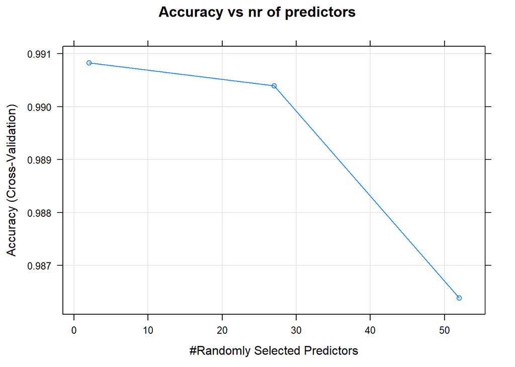

```r
plot(RF_model, main="Accuracy vs nr of predictors")
```

At a first glance, the plot tells us that RF algorithm performs much better than CT in terms of accuracy. To further investigate, let’s look at the confusion matrix and accuracy as we’ve previously done.

```r
RF_prediction = predict(RF_model,newdata=Test_1)

RF_ConfusionM = confusionMatrix(factor(Test_1$classe),RF_prediction)

# confusion matrix
RF_ConfusionM$table
```

```
##           Reference
## Prediction    A    B    C    D    E
##          A 1674    0    0    0    0
##          B    9 1126    4    0    0
##          C    1    9 1015    1    0
##          D    0    0   18  945    1
##          E    0    0    0    0 1082
```

```r
# Accuracy
RF_ConfusionM$overall[1]
```

```
##  Accuracy
## 0.9926933
```

This shows a very good result, telling us that accuracy is higher than before (~99%).

### Boosting

Finally, let’s take a look at boosting algorithm. *gbm* allows us to perform boosting with trees within the caret package.

```r
GBM_model = train(classe~., data=Train_1, method="gbm", trControl=train_Control, verbose=FALSE)

print(GBM_model)
```

```
## Stochastic Gradient Boosting
##
## 13737 samples
##    52 predictor
##     5 classes: 'A', 'B', 'C', 'D', 'E'
##
## No pre-processing
## Resampling: Cross-Validated (5 fold)
## Summary of sample sizes: 10989, 10988, 10990, 10990, 10991
## Resampling results across tuning parameters:
##
##   interaction.depth  n.trees  Accuracy   Kappa
##   1                   50      0.7507472  0.6840275
##   1                  100      0.8180095  0.7696643
##   1                  150      0.8501864  0.8104313
##   2                   50      0.8526617  0.8132969
##   2                  100      0.9050748  0.8798603
##   2                  150      0.9306254  0.9122183
##   3                   50      0.8951745  0.8672766
##   3                  100      0.9419086  0.9264998
##   3                  150      0.9595249  0.9487976
##
## Tuning parameter 'shrinkage' was held constant at a value of 0.1
##
## Tuning parameter 'n.minobsinnode' was held constant at a value of 10
## Accuracy was used to select the optimal model using the largest value.
## The final values used for the model were n.trees = 150, interaction.depth =
##  3, shrinkage = 0.1 and n.minobsinnode = 10.
```

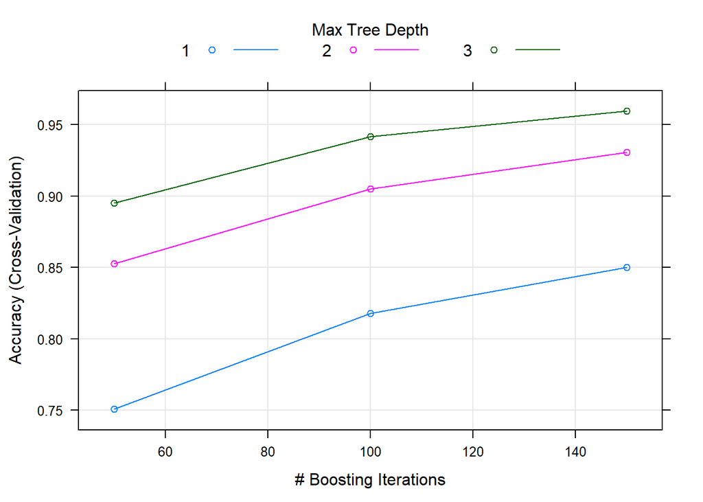

```r
plot(GBM_model)
```

Again, let’s look at confusion matrix and accuracy to compare results.

```r
GBM_prediction = predict(GBM_model,newdata=Test_1)

GBM_ConfusionM = confusionMatrix(factor(Test_1$classe),GBM_prediction)

# confusion matrix
GBM_ConfusionM$table
```

```
##           Reference
## Prediction    A    B    C    D    E
##          A 1643   22    7    1    1
##          B   38 1071   28    2    0
##          C    0   30  981   14    1
##          D    1    2   36  917    8
##          E    0    8    8   16 1050
```

```r
# Accuracy
GBM_ConfusionM$overall[1]
```

```
##  Accuracy
## 0.9621071
```

It emerges that accuracy is higher than CT case, but still lower than that of RF (~96%).

## Conclusion

After having carried out our analysis using three different algorithms, we can conclude that RF performs better than the others in terms of accuracy. Hence, we can use it to predict the variable of interest, classe in this case.

```r
Pred_Final = predict(RF_model,newdata=TestData)
Pred_Final
```

```
##  [1] B A B A A E D B A A B C B A E E A B B B
## Levels: A B C D E
```